# John’s Section

John Nobles, Adam Gullion, Jonathan Aguilar

2025-04-17

# Variables of interest (hitting):

- launch angle (`launch_angle_avg`)
- exit velocity (`exit_velocity_avg`)
- hard-hit rate (`hard_hit_percent`)
- barrel batted rate (`barrel_batted_rate`)
- strikeout percentage (`k_percent`)
- and more

# Boxplots of strikeout percent by year

- Increase in strikeout percentage from 2015 through 2020 (Spider tack)
- 2 year decline after 2020 (crackdown on Spider tack)
- In 2023 & 2024, median % rose above 20% (result of statcast)

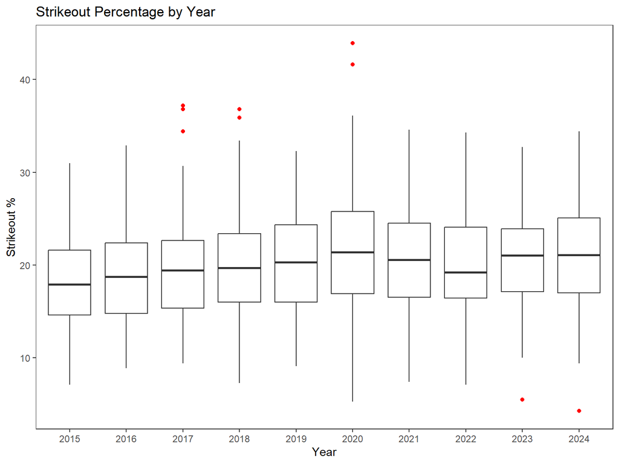

# Average strikeout by Year Trend Line

- Taking a look at the average strikeout percentage by year and a trend line for this data, we can see how our analysis from the previous slide is backed up.

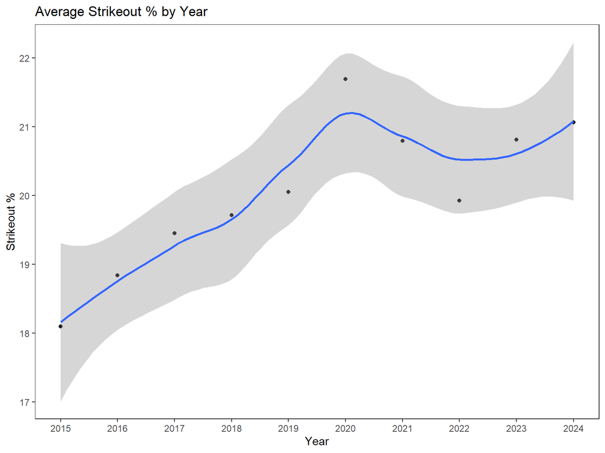

# A graph of the boxplots for hard hitting percentage by year

- Layered on top (red dots) is the **average** hard hit percentage for each year.

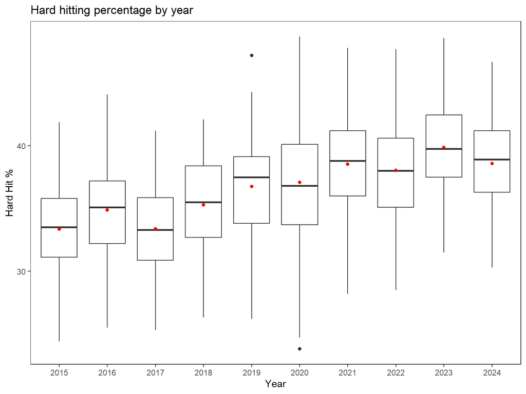

# Zooming in to *just* the average hard hit percent for each year, we can see a clearer correlation.

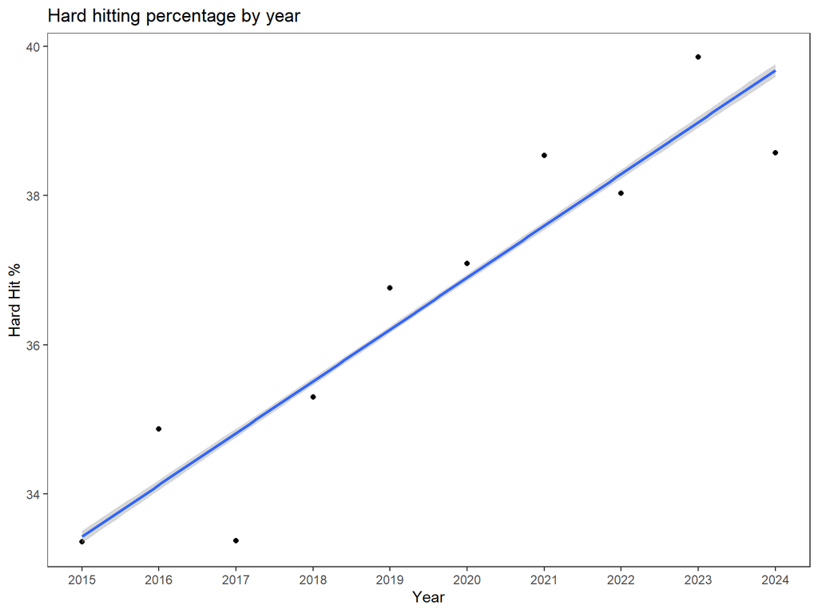

# A violin graph of this data.

- We continue to see the upward trend in hard hit percentage
- What’s with the elongated violin in 2020? As sample size decreases, standard deviation increases!

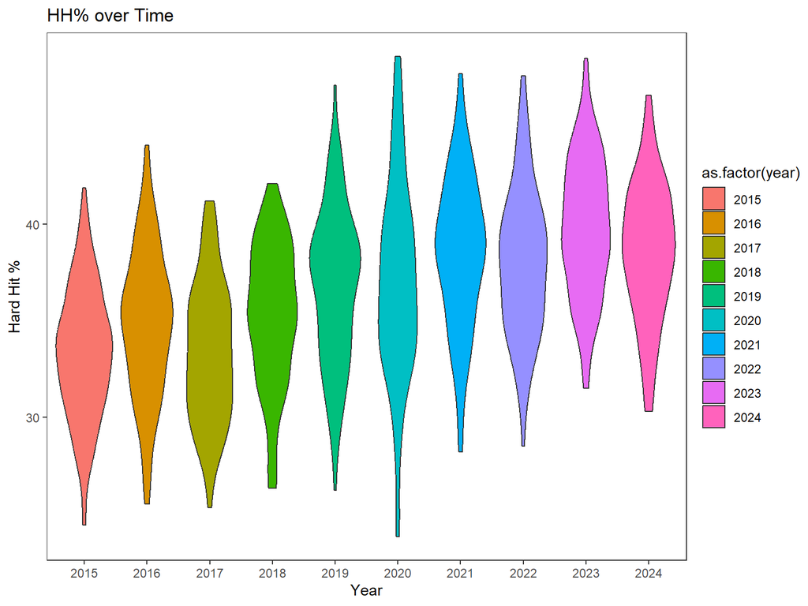